# **Time Series Analysis - Task 1**

Sofía Gianelli and Roberto Álvarez

## Dataset Import and Libraries

```python
from google.colab import drive
drive.mount('/content/drive')
```

```python
from google.colab import files
uploaded = files.upload()
```

Upload widget is only available when the cell has been executed in the current browser session. Please rerun this cell to enable.

```
Saving air traffic.xlsx to air traffic.xlsx
```

```python
import pandas as pd
import numpy as np
df = pd.read_excel('air traffic.xlsx')
from statsmodels.tsa.seasonal import seasonal_decompose
from statsmodels.tsa.holtwinters import ExponentialSmoothing
import matplotlib.pyplot as plt
import seaborn as sns
from keras.models import Sequential
from keras.layers import LSTM, Dense
from sklearn.preprocessing import MinMaxScaler
from sklearn.metrics import mean_squared_error
import matplotlib.pyplot as plt
import statsmodels.api as sm
from scipy.signal import periodogram
from sklearn.metrics import mean_absolute_error
```

```python
df.head()
```

|  | Year | Month | Dom_Pax | Int_Pax | Pax | Dom_Flt | Int_Flt | Flt | Dom_RPM | Int_RPM | RPM | Dom_ASM | Int_ASM | ASM | Dom_LF | Int_LF | LF |
| --- | --- | --- | --- | --- | --- | --- | --- | --- | --- | --- | --- | --- | --- | --- | --- | --- | --- |
| 0 | 2003 | 1 | 43,032,450 | 4,905,830 | 47,938,280 | 785.160 | 57.667 | 842.827 | 36,211,422 | 12,885,980 | 49,097,402 | 56,191,300 | 17,968,572 | 74,159,872 | 64.44 | 71.71 | 66.20 |
| 1 | 2003 | 2 | 41,166,780 | 4,245,366 | 45,412,146 | 690.351 | 51.259 | 741.610 | 34,148,439 | 10,715,468 | 44,863,907 | 50,088,434 | 15,587,880 | 65,676,314 | 68.18 | 68.74 | 68.31 |
| 2 | 2003 | 3 | 49,992,700 | 5,008,613 | 55,001,313 | 797.194 | 58.926 | 856.120 | 41,774,564 | 12,567,068 | 54,341,633 | 57,592,901 | 17,753,174 | 75,346,075 | 72.53 | 70.79 | 72.12 |
| 3 | 2003 | 4 | 47,033,260 | 4,345,444 | 51,378,704 | 766.260 | 55.005 | 821.265 | 39,465,980 | 10,370,592 | 49,836,572 | 54,639,679 | 15,528,761 | 70,168,440 | 72.23 | 66.78 | 71.02 |
| 4 | 2003 | 5 | 49,152,352 | 4,610,834 | 53,763,186 | 789.397 | 55.265 | 844.662 | 41,001,934 | 11,575,026 | 52,576,960 | 55,349,897 | 15,629,821 | 70,979,718 | 74.08 | 74.06 | 74.07 |

```python
df.info()
```

```
<class 'pandas.core.frame.DataFrame'>
RangeIndex: 204 entries, 0 to 203
Data columns (total 17 columns):
 #   Column   Non-Null Count  Dtype
---  ------   --------------  -----
 0   Year     204 non-null    int64
 1   Month    204 non-null    int64
 2   Dom_Pax  204 non-null    object
 3   Int_Pax  204 non-null    object
 4   Pax      204 non-null    object
 5   Dom_Flt  204 non-null    float64
 6   Int_Flt  204 non-null    float64
 7   Flt      204 non-null    float64
 8   Dom_RPM  204 non-null    object
 9   Int_RPM  204 non-null    object
 10  RPM      204 non-null    object
 11  Dom_ASM  204 non-null    object
 12  Int_ASM  204 non-null    object
 13  ASM      204 non-null    object
 14  Dom_LF   204 non-null    float64
 15  Int_LF   204 non-null    float64
 16  LF       204 non-null    float64
dtypes: float64(6), int64(2), object(9)
memory usage: 27.2+ KB
```

## Preprocessing

```python
## Missing values

#Calculate the percentage of missing values for each column
missing_percentage = (df.isnull().sum() / len(df)) * 100

# Sort columns by their missing percentage in descending order
missing_percentage = missing_percentage.sort_values(ascending=False)

# Display the result
print(missing_percentage)
```

```
Year       0.0
Int_RPM    0.0
Int_LF     0.0
Dom_LF     0.0
ASM        0.0
Int_ASM    0.0
Dom_ASM    0.0
RPM        0.0
Dom_RPM    0.0
Month      0.0
Flt        0.0
Int_Flt    0.0
Dom_Flt    0.0
Pax        0.0
Int_Pax    0.0
Dom_Pax    0.0
LF         0.0
dtype: float64
```

## Our Project

In our analysis, we have focused on exploring the seasonality in flight data, particularly in the context of airport traffic and airline operations from the U.S. Airline Traffic Data. We have applied various descriptive techniques to understand the patterns and trends within the flight series. These techniques include smoothing methods like Holt-Winter models, harmonic analysis, and neural networks. By employing these techniques, we aimed to uncover the underlying seasonal variations, identify trends, and develop accurate forecasting models for both domestic and international flights.

## Data split 80%-20%

```python
# Convert object-type columns to numeric format
for col in df.columns:
    if df[col].dtype == 'object':
        df[col] = pd.to_numeric(df[col].str.replace(',', ''), errors='coerce')

# Combine 'Year' and 'Month' columns to create a new 'Date' column
df['Date'] = pd.to_datetime(df[['Year', 'Month']].astype(str).agg('-'.join, axis=1))

# Set the 'Date' column as the index
df.set_index("Date", inplace=True)

# Set the frequency of the index
df.index.freq = 'MS'  # 'MS' stands for Month Start

# Optionally, you can drop the 'Year' and 'Month' columns if they are no longer needed
df.drop(columns=['Year', 'Month'], inplace=True)

# Calculate the index to split the data (80% for training, 20% for testing)
split_index = int(len(df) * 0.80)

# Split the data into training (80%) and testing (20%) sets
train_data = df.iloc[:split_index]
test_data = df.iloc[split_index:]

# Display the shapes of the training and testing sets
print("Training data shape:", train_data.shape)
print("Testing data shape:", test_data.shape)
```

```
Training data shape: (163, 15)
Testing data shape: (41, 15)
```

**Plot the original series**

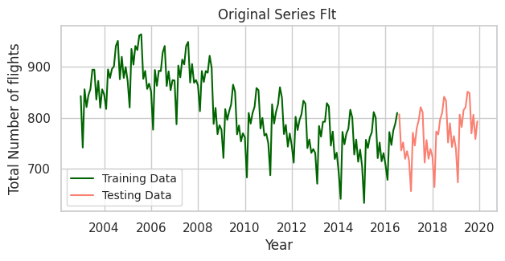

```python
# Set the style
sns.set(style="whitegrid")

# Create the plot
plt.figure(figsize=(7, 3))
sns.lineplot(data=train_data, x=train_data.index, y="Flt", color="darkgreen", label="Training Data")
sns.lineplot(data=test_data, x=test_data.index, y="Flt", color="salmon", label="Testing Data")

# Set labels and title
plt.xlabel("Year")
plt.ylabel("Total Number of flights")
plt.title("Original Series Flt ")

# Set legend
plt.legend(loc='lower left', fontsize='small')

# Show plot
plt.show()
```

The original series represents the total number of flights over time, spanning from 2003 to 2019. The data is organized monthly, with each data point indicating the total number of flights recorded for that specific month. The series has been split into training and testing datasets to facilitate the development and evaluation of predictive models. The training data is used to train the models, while the testing data serves to assess their performance and generalization ability. This splitting ensures that the models are trained on historical data and tested on unseen future data, mimicking real-world scenarios. We can see that since the year 2008 there is a clear lower trend in the number of flights that seems to pick it up from 2016 onwards.

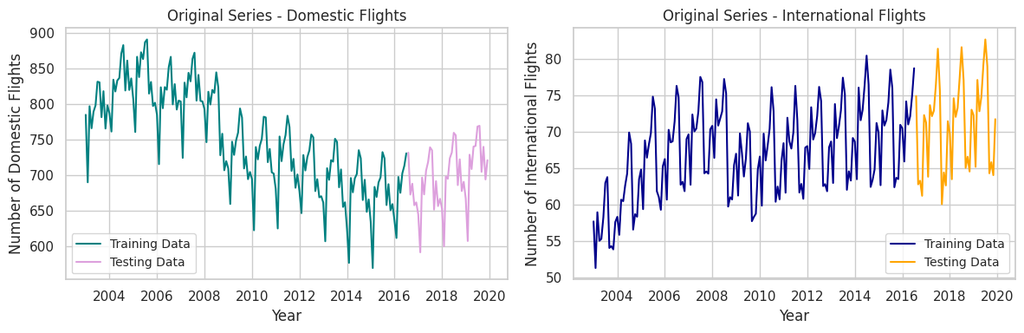

```python
# Plot original series for domestic and international
# Create the subplots
fig, axs = plt.subplots(1, 2, figsize=(12, 4))

# Plot for Domestic Flights (left subplot)
sns.lineplot(data=train_data, x=train_data.index, y="Dom_Flt", color="teal", label="Training Data", ax=axs[0])
sns.lineplot(data=test_data, x=test_data.index, y="Dom_Flt", color="plum", label="Testing Data", ax=axs[0])
axs[0].set_xlabel("Year")
axs[0].set_ylabel("Number of Domestic Flights")
axs[0].set_title("Original Series - Domestic Flights")
axs[0].legend(loc='lower left', fontsize=10)

# Plot for International Flights (right subplot)
sns.lineplot(data=train_data, x=train_data.index, y="Int_Flt", color="darkblue", label="Training Data", ax=axs[1])
sns.lineplot(data=test_data, x=test_data.index, y="Int_Flt", color="orange", label="Testing Data", ax=axs[1])
axs[1].set_xlabel("Year")
axs[1].set_ylabel("Number of International Flights")
axs[1].set_title("Original Series - International Flights")
axs[1].legend(loc='lower right', fontsize=10)

# Adjust layout
plt.tight_layout()

# Show plots
plt.show()
```

The first thing to note is that the number of domestic flights over the years is much bigger than the international flights.

The decrease in the total number of domestic flights in the US since 2008, while the number of international flights increase in trend, can be attributed to several factors. One possible explanation is the impact of the 2008 financial crisis, which led to a decrease in domestic air travel demand due to economic decline and reduced consumer spending. Additionally, changes in consumer preferences, such as a shift towards alternative modes of transportation for domestic travel, could also contribute to this trend. Furthermore, the rise of teleconferencing and remote work may have reduced the need for domestic business travel, while international travel demand increase a little bit. These factors, among others, may have influenced the diverging trends in domestic and international flight numbers.

## Holt-Winters Forecasting

The Holt-Winters model is a forecasting method that is used for data exhibiting both a trend and a seasonal variation. It comprises the forecast equation and three smoothing equations: one for the level ($a_t$), one for the trend ($b_t$), and one for the seasonal component ($S_t$), with corresponding smoothing parameters $\alpha$, $\beta$, and $\gamma$. The model is defined by its three order parameters: $\alpha$ (the coefficient for the level smoothing), $\beta$ (the coefficient for the trend smoothing), and $\gamma$ (the coefficient for the seasonal smoothing). It applies triple exponential smoothing for level, trend, and seasonal components. The method can handle both additive and multiplicative seasonality, where each season changes by a constant number or a factor, respectively. In our work we have used the additive model because is useful when the seasonal variation is relatively constant over time.

#### Decompostion

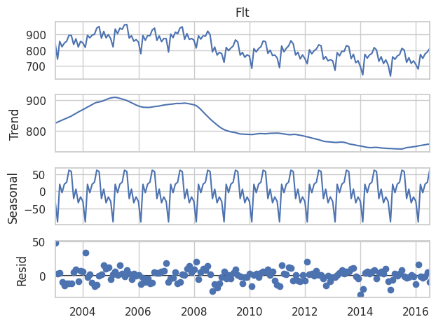

```python
dec_result_flt = seasonal_decompose(train_data["Flt"], model="additive", extrapolate_trend=True)
dec_result_flt.plot()
plt.show()
```

### Flight Model

```python
flt_model = ExponentialSmoothing(train_data['Flt'], seasonal_periods=12, trend='add', seasonal='add')
flt_fit = flt_model.fit()
print("Flights Model Parameters:",flt_fit.params)
```

[output not shown]

```python
print("Flights Estimated Alpha:", flt_fit.params['smoothing_level'])
```

```
Flights Estimated Alpha: 0.7391110913644988
```

```python
print("Flights Estimated Beta:", flt_fit.params['smoothing_trend'])
```

```
Flights Estimated Beta: 0.00010038207823431589
```

```python
print("Flights Estimated Gamma:", flt_fit.params['smoothing_seasonal'])
```

```
Flights Estimated Gamma: 1.1589410354411145e-05
```

We used the additive model so we can come up with the regular equation form:

$\hat{z}_{t+h} + hb_t + S_{t-p+(h−1)modp}$

where $a_t$ is the level, $b_t$ is the trend and $S_t$ is the seasonal component. We can defined the formulas in the following way:

- $a_t = α(z_t - S_{t-p}) + (1-α)(a_{t-1} + b_{t-1})$
- $b_t = β(a_t - a_{t-1}) + (1-β)b_{t-1}$
- $S_t = γ(z_t - a_t) + (1-γ)S_{t-p}$

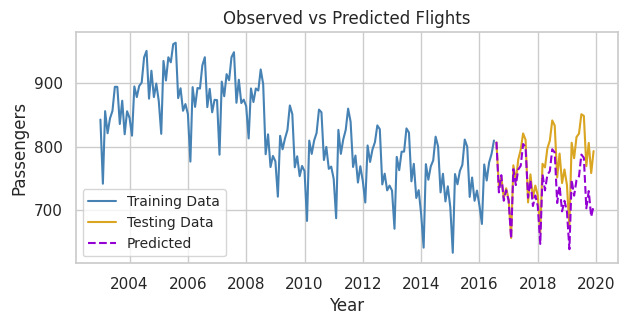

```python
flt_predictions = flt_fit.predict(start=test_data.index[0], end=test_data.index[-1])
flt_predictions = pd.DataFrame(flt_predictions, index=test_data.index, columns=["Predicted Flights"])
plt.figure(figsize=(7, 3)) # Adjusting the figure size
plt.plot(train_data['Flt'], label='Training Data', color='steelblue')
plt.plot(test_data['Flt'], label='Testing Data', color='#DAA520')
plt.plot(flt_predictions, label='Predicted', linestyle='--', color='darkviolet')
plt.xlabel("Year")
plt.ylabel("Passengers")
plt.title("Observed vs Predicted Flights")
plt.legend(loc='lower left',fontsize='small')
plt.show()
```

After performing seasonal decomposition, predictions were made for the total number of flights. The model parameters were fitted to the training data, and the predicted values were generated for the test data period. These predictions were then plotted alongside the observed training and testing data for visual comparison. The observed plot reveals a slight upward trend in the testing data, while the predicted values exhibit a subtle downward trend. This contrast suggests a discrepancy between the model's predictions and the actual testing data trend direction.

```python
%%capture
#solo para que lo veamos nosostros
pd.options.display.float_format = '{:.0f}'.format
# Concatenate the predicted values and actual values into a DataFrame
flt_results_table = pd.concat([flt_predictions, test_data['Flt']], axis=1)
flt_results_table.columns = ['Predicted Flights', 'Actual Flights']

# Print the table
print(flt_results_table)
```

#### Domestic vs International

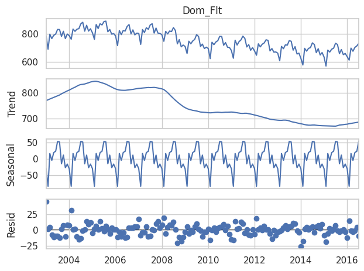

```python
# Perform seasonal decomposition for domestic flights
dec_result_dom_flt = seasonal_decompose(train_data["Dom_Flt"], model="additive", extrapolate_trend=True)
dec_result_dom_flt.plot()
plt.show()
```

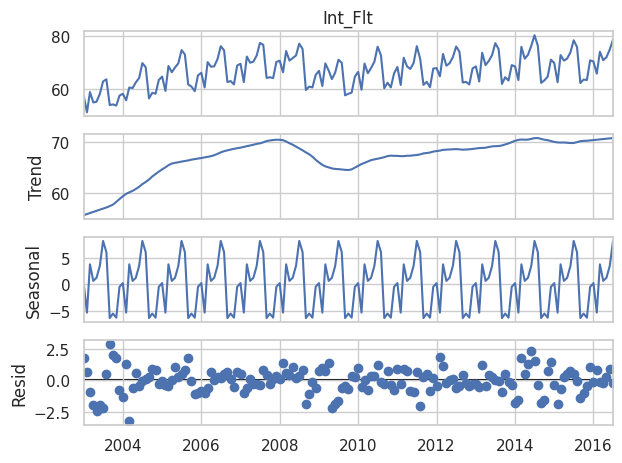

```python
# Perform seasonal decomposition for international flights
dec_result_int_flt = seasonal_decompose(train_data["Int_Flt"], model="additive", extrapolate_trend=True)
dec_result_int_flt.plot()
plt.show()
```

```python
dom_flt_model = ExponentialSmoothing(train_data['Dom_Flt'], seasonal_periods=12, trend='add', seasonal='add')
dom_flt_fit = dom_flt_model.fit()
dom_flt_predictions = dom_flt_fit.predict(start=test_data.index[0], end=test_data.index[-1])
dom_flt_predictions = pd.DataFrame(dom_flt_predictions, index=test_data.index, columns=["Predicted Domestic Flights"])
int_flt_model = ExponentialSmoothing(train_data['Int_Flt'], seasonal_periods=12, trend='add', seasonal='add')
int_flt_fit = int_flt_model.fit()
int_flt_predictions = int_flt_fit.predict(start=test_data.index[0], end=test_data.index[-1])
int_flt_predictions = pd.DataFrame(int_flt_predictions, index=test_data.index, columns=["Predicted International Flights"])
```

```python
print("Domestic Flights Estimated Alpha:", dom_flt_fit.params['smoothing_level'])
print("Domestic Flights Estimated Beta:", dom_flt_fit.params['smoothing_trend'])
print("Domestic Flights Estimated Gamma:", dom_flt_fit.params['smoothing_seasonal'])
```

```
Domestic Flights Estimated Alpha: 0.7364143190539922
Domestic Flights Estimated Beta: 3.2700533659519002e-06
Domestic Flights Estimated Gamma: 4.5179870889406126e-07
```

The seasonal decomposition analysis of international flight data reveals distinctive trends compared to domestic flights which are very similar as the total number of flights. In particular, the trend component showcases an initial upward trajectory until approximately 2008, followed by a decline until 2010, and then a subsequent, though less pronounced, increase. The seasonal variation, while consistent over time, exhibits a left-skewed distribution, differing from the patterns observed in domestic flights. Residual analysis indicates that the deviations from the model are relatively small, with most residuals clustering around the zero line, although some outliers are present, especially between 2.5 and -2.5, suggesting occasional discrepancies in the model's fit to the data.

```python
print("International Flights Estimated Alpha:", int_flt_fit.params['smoothing_level'])
print("International Flights Estimated Beta:", int_flt_fit.params['smoothing_trend'])
print("International Flights Estimated Gamma:", int_flt_fit.params['smoothing_seasonal'])
```

```
International Flights Estimated Alpha: 0.6936112244695879
International Flights Estimated Beta: 0.0
International Flights Estimated Gamma: 0.0
```

In our time series (total of International Flights):

- $a_t = 0.7(intflight_t - S_{t-12}) + 0.3(a_{t-1} + b_{t-1})$
- $b_t = b_{t-1}$
- $S_t = S_{t-12}$

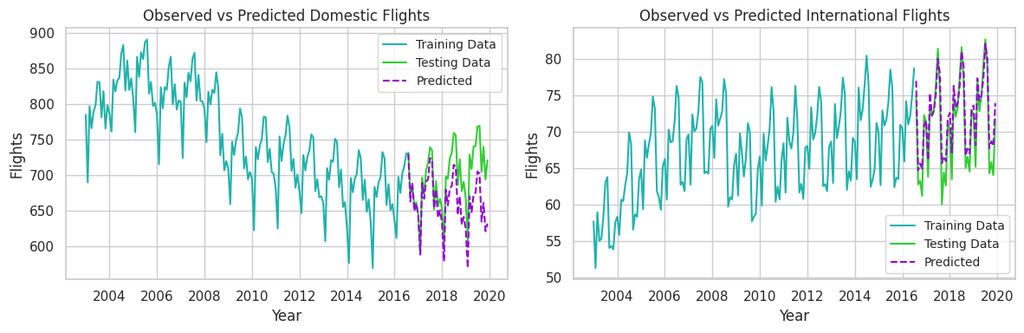

```python
# Create the subplots
fig, axs = plt.subplots(1, 2, figsize=(12, 4))

# First subplot: Domestic Flights
axs[0].plot(train_data['Dom_Flt'], label='Training Data', color='#20B2AA')
axs[0].plot(test_data['Dom_Flt'], label='Testing Data', color='#32CD32')
axs[0].plot(dom_flt_predictions, label='Predicted', linestyle='--', color='darkviolet')
axs[0].set_xlabel("Year")
axs[0].set_ylabel("Flights")
axs[0].set_title("Observed vs Predicted Domestic Flights")
axs[0].legend(loc='best', fontsize=10)

# Second subplot: International Flights
axs[1].plot(train_data['Int_Flt'], label='Training Data', color='#20B2AA')
axs[1].plot(test_data['Int_Flt'], label='Testing Data', color='#32CD32')
axs[1].plot(int_flt_predictions, label='Predicted', linestyle='--', color='darkviolet')
axs[1].set_xlabel("Year")
axs[1].set_ylabel("Flights")
axs[1].set_title("Observed vs Predicted International Flights")
axs[1].legend(loc='best', fontsize=10)

# Adjust the layouts
plt.tight_layout()

# Show the plots
plt.show()
```

Following a similar analysis, predictions were made separately for domestic and international flights. The plots depict notable differences in the predictions between domestic and international flights. In the case of domestic flights, the predicted values closely resemble the overall trend observed in the total number of flights. However, for international flights, the predictions for the international flights follow the same tendency as the testing data; however, they fall a bit short in the trajectory length.

```python
# MSE Flights
MSE_flt_HW = mean_squared_error(test_data['Flt'], flt_predictions)
# MSE Domestic and International Flights
MSE_dom_flt_HW = mean_squared_error(test_data['Dom_Flt'], dom_flt_predictions)
MSE_int_flt_HW = mean_squared_error(test_data['Int_Flt'], int_flt_predictions)
holt_winter_results = {
    'Metric': [ 'MSE Flights', 'MSE Domestic Flights', 'MSE International Flights'],
    'MSE Value': [ MSE_flt_HW, MSE_dom_flt_HW, MSE_int_flt_HW]}
holt_winter_results = pd.DataFrame(holt_winter_results) #creating th data frame
print(holt_winter_results)
```

```
                      Metric  MSE Value
0                MSE Flights       1727
1       MSE Domestic Flights       1804
2  MSE International Flights          5
```

## Neural networks

Neural networks, inspired by the brain's structure, are powerful tools for analyzing complex relationships in data. In time series forecasting, Long Short-Term Memory (LSTM) networks, a type of artificial neural network, stand out for their ability to capture temporal patterns and make accurate predictions based on historical data. By leveraging LSTM layers, these networks excel at learning from past observations to forecast future values. The program seen in class and used in this project, utilizes Keras to build an LSTM model tailored for time series forecasting, demonstrating how neural networks can effectively predict trends in sequential data.

### Flights

```python
%%capture
# Scale the data using MinMaxScaler for only the 'Flt' variable
scaler = MinMaxScaler(feature_range=(0, 1))
train_flt_scaled = scaler.fit_transform(train_data[['Flt']])
test_flt_scaled = scaler.transform(test_data[['Flt']])
# Prepare the training data for LSTM using only the 'Flt' variable
X_flt_train, y_flt_train = [], []
for i in range(12, len(train_flt_scaled)):
    X_flt_train.append(train_flt_scaled[i-12:i, 0])
    y_flt_train.append(train_flt_scaled[i, 0])
X_flt_train, y_flt_train = np.array(X_flt_train), np.array(y_flt_train)

# Reshape the data for LSTM
X_flt_train = np.reshape(X_flt_train, (X_flt_train.shape[0], X_flt_train.shape[1], 1))

# Build and compile the LSTM model
model = Sequential([
    LSTM(50, return_sequences=True, input_shape=(X_flt_train.shape[1], 1)),
    LSTM(50),
    Dense(1)
])
model.compile(loss='mean_squared_error', optimizer='adam')

# Train the model
model.fit(X_flt_train, y_flt_train, epochs=100, batch_size=32)

# Prepare the test data for prediction
X_flt_test = []
for i in range(len(test_flt_scaled) - 12, len(test_flt_scaled)):
    X_flt_test.append(test_flt_scaled[i-12:i, 0])
X_flt_test = np.array(X_flt_test)

# Reshape the data for LSTM
X_flt_test = np.reshape(X_flt_test, (X_flt_test.shape[0], X_flt_test.shape[1], 1))

# Predict the test data
flt_predictions2_scaled = model.predict(X_flt_test)

# Inverse transform the predictions to get the actual passenger values
flt_predictions2 = scaler.inverse_transform(flt_predictions2_scaled)
```

```python
# DataFrame to display the results
flt_result2_df = pd.DataFrame({'Real test data': test_data['Flt'].values[-12:], 'Predicted Flights': flt_predictions2[:, 0]})
print(flt_result2_df)
```

```
    Real test data  Predicted Flights
0              740                711
1              673                715
2              806                753
3              782                772
4              815                800
5              821                820
6              851                832
7              849                817
8              769                785
9              806                778
10             758                751
11             793                742
```

```python
# Calculate Mean Squared Error (MSE)
MSE_flt_NN = mean_squared_error(test_data['Flt'][-12:].values, flt_predictions2[:, 0])
print("Mean Squared Error (MSE):", MSE_flt_NN)

# Calculate Mean Absolute Error (MAE)
MAE_flt = mean_absolute_error(test_data['Flt'][-12:].values, flt_predictions2[:, 0])
print("Mean Absolute Error (MAE):", MAE_flt)

# Calculate Root Mean Squared Error (RMSE)
RMSE_flt = np.sqrt(mean_squared_error(test_data['Flt'][-12:].values, flt_predictions2[:, 0]))
print("Root Mean Squared Error (RMSE):", RMSE_flt)
```

```
Mean Squared Error (MSE): 900.4835099333167
Mean Absolute Error (MAE): 25.213344970703133
Root Mean Squared Error (RMSE): 30.008057416855838
```

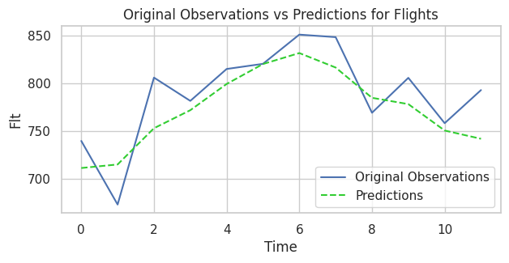

```python
# Plotting original observations and predictions
plt.figure(figsize=(7, 3))
plt.plot(test_data['Flt'][-12:].values, label="Original Observations")
plt.plot(flt_predictions2[:, 0], label="Predictions", linestyle='--',color='limegreen')
plt.legend(loc='best')
plt.title("Original Observations vs Predictions for Flights")
plt.xlabel("Time")
plt.ylabel("Flt")
plt.show()
```

This plot showcases the past year's predicted and actual "Flt" values, revealing a remarkable match between the LSTM model's predictions and real-world observations . This success highlights the model's ability to learn underlying patterns, enabling accurate flight number forecasts. While just a glimpse, the plot demonstrates the model's strong generalization, effectively capturing the nuances of actual flight data. This bodes well for real-world applications, solidifying the LSTM model's reliability in predicting flight trends and its potential as a valuable tool for further analysis and forecasting.

#### Domestic vs International

```python
%%capture
# Scale the data using MinMaxScaler for domestic flights
scaler_dom = MinMaxScaler(feature_range=(0, 1))
train_dom_scaled = scaler_dom.fit_transform(train_data[['Dom_Flt']])
test_dom_scaled = scaler_dom.transform(test_data[['Dom_Flt']])

# Scale the data using MinMaxScaler for international flights
scaler_int = MinMaxScaler(feature_range=(0, 1))
train_int_scaled = scaler_int.fit_transform(train_data[['Int_Flt']])
test_int_scaled = scaler_int.transform(test_data[['Int_Flt']])

# Define a function to prepare data for LSTM
def prepare_data(data_scaled):
    X_train, y_train = [], []
    for i in range(12, len(data_scaled)):
        X_train.append(data_scaled[i-12:i, 0])
        y_train.append(data_scaled[i, 0])
    X_train, y_train = np.array(X_train), np.array(y_train)
    X_train = np.reshape(X_train, (X_train.shape[0], X_train.shape[1], 1))
    return X_train, y_train

# Prepare the training data for domestic flights
X_dom_train, y_dom_train = prepare_data(train_dom_scaled)

# Prepare the training data for international flights
X_int_train, y_int_train = prepare_data(train_int_scaled)

# Build and compile the LSTM model for domestic flights
model_dom = Sequential([
    LSTM(50, return_sequences=True, input_shape=(X_dom_train.shape[1], 1)),
    LSTM(50),
    Dense(1)
])
model_dom.compile(loss='mean_squared_error', optimizer='adam')

# Build and compile the LSTM model for international flights
model_int = Sequential([
    LSTM(50, return_sequences=True, input_shape=(X_int_train.shape[1], 1)),
    LSTM(50),
    Dense(1)
])
model_int.compile(loss='mean_squared_error', optimizer='adam')

# Train the LSTM model for domestic flights
model_dom.fit(X_dom_train, y_dom_train, epochs=100, batch_size=32)

# Train the LSTM model for international flights
model_int.fit(X_int_train, y_int_train, epochs=100, batch_size=32)

# Prepare the test data for prediction for domestic flights
X_dom_test = []
for i in range(len(test_dom_scaled) - 12, len(test_dom_scaled)):
    X_dom_test.append(test_dom_scaled[i-12:i, 0])
X_dom_test = np.array(X_dom_test)
X_dom_test = np.reshape(X_dom_test, (X_dom_test.shape[0], X_dom_test.shape[1], 1))

# Prepare the test data for prediction for international flights
X_int_test = []
for i in range(len(test_int_scaled) - 12, len(test_int_scaled)):
    X_int_test.append(test_int_scaled[i-12:i, 0])
X_int_test = np.array(X_int_test)
X_int_test = np.reshape(X_int_test, (X_int_test.shape[0], X_int_test.shape[1], 1))

# Predict the test data for domestic flights
dom_predictions_scaled = model_dom.predict(X_dom_test)
dom_predictions = scaler_dom.inverse_transform(dom_predictions_scaled)

# Predict the test data for international flights
int_predictions_scaled = model_int.predict(X_int_test)
int_predictions = scaler_int.inverse_transform(int_predictions_scaled)
```

```python
# Display the results for domestic flights
result_dom_df = pd.DataFrame({
    'Real test data (Domestic)': test_data['Dom_Flt'][-12:].values,
    'Predicted Flights (Domestic)': dom_predictions[:, 0]
})
print("Results for Domestic Flights:")
print(result_dom_df)

# Display the results for international flights
result_int_df = pd.DataFrame({
    'Real test data (International)': test_data['Int_Flt'][-12:].values,
    'Predicted Flights (International)': int_predictions[:, 0]
})
print("\nResults for International Flights:")
print(result_int_df)
```

```
Results for Domestic Flights:
    Real test data (Domestic)  Predicted Flights (Domestic)
0                         668                           653
1                         608                           660
2                         729                           682
3                         709                           695
4                         740                           711
5                         741                           721
6                         769                           723
7                         770                           713
8                         705                           696
9                         740                           691
10                        694                           676
11                        721                           673

Results for International Flights:
    Real test data (International)  Predicted Flights (International)
0                               72                                 67
1                               65                                 67
2                               77                                 71
3                               73                                 72
4                               75                                 74
5                               79                                 76
6                               83                                 77
7                               79                                 75
8                               64                                 69
9                               66                                 68
10                              64                                 68
11                              72                                 69
```

```python
# Calculate Mean Squared Error (MSE) for domestic flights
MSE_dom_flt_NN = mean_squared_error(test_data['Dom_Flt'][-12:].values, dom_predictions[:, 0])
print("Mean Squared Error (MSE) for Domestic Flights:", MSE_dom_flt_NN)

# Calculate Mean Absolute Error (MAE) for domestic flights
MAE_dom_flt_NN = mean_absolute_error(test_data['Dom_Flt'][-12:].values, dom_predictions[:, 0])
print("Mean Absolute Error (MAE) for Domestic Flights:", MAE_dom_flt_NN)

# Calculate Root Mean Squared Error (RMSE) for domestic flights
RMSE_dom_flt_NN = np.sqrt(mean_squared_error(test_data['Dom_Flt'][-12:].values, dom_predictions[:, 0]))
print("Root Mean Squared Error (RMSE) for Domestic Flights:", RMSE_dom_flt_NN)

# Calculate Mean Squared Error (MSE) for international flights
MSE_int_flt_NN = mean_squared_error(test_data['Int_Flt'][-12:].values, int_predictions[:, 0])
print("\nMean Squared Error (MSE) for International Flights:", MSE_int_flt_NN)

# Calculate Mean Absolute Error (MAE) for international flights
MAE_int_flt_NN = mean_absolute_error(test_data['Int_Flt'][-12:].values, int_predictions[:, 0])
print("Mean Absolute Error (MAE) for International Flights:", MAE_int_flt_NN)

# Calculate Root Mean Squared Error (RMSE) for international flights
RMSE_int_flt_NN = np.sqrt(mean_squared_error(test_data['Int_Flt'][-12:].values, int_predictions[:, 0]))
print("Root Mean Squared Error (RMSE) for International Flights:", RMSE_int_flt_NN)
```

```
Mean Squared Error (MSE) for Domestic Flights: 1420.9311231148406
Mean Absolute Error (MAE) for Domestic Flights: 33.65163468424478
Root Mean Squared Error (RMSE) for Domestic Flights: 37.695240059122064

Mean Squared Error (MSE) for International Flights: 14.294663395933666
Mean Absolute Error (MAE) for International Flights: 3.344998235066729
Root Mean Squared Error (RMSE) for International Flights: 3.780828400752098
```

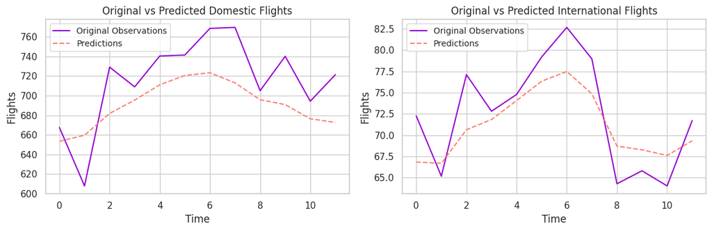

```python
# Set the figure size
plt.figure(figsize=(12, 4))

# Plotting original observations and predictions for domestic flights
plt.subplot(1, 2, 1)
plt.plot(test_data['Dom_Flt'][-12:].values, label="Original Observations", color="darkviolet")
plt.plot(dom_predictions[:, 0], label="Predictions", linestyle='--', color='salmon')
plt.legend(loc='best',fontsize=10)
plt.title("Original vs Predicted Domestic Flights")
plt.xlabel("Time")
plt.ylabel("Flights")

# Plotting original observations and predictions for international flights
plt.subplot(1, 2, 2)
plt.plot(test_data['Int_Flt'][-12:].values, label="Original Observations", color="darkviolet")
plt.plot(int_predictions[:, 0], label="Predictions", linestyle='--', color='salmon')
plt.legend(loc='best',fontsize=10)
plt.title("Original vs Predicted International Flights")
plt.xlabel("Time")
plt.ylabel("Flights")

plt.tight_layout()  # Adjust layout to prevent overlap
plt.show()
```

Diving deeper, we have domestic and international flights separately as we have been doing. The domestic subplot reveals a consistent underestimation by the model, with predicted values consistently below actual observations. This gap seems wider compared to total flights, suggesting the model struggles more with domestic forecasts. Conversely, international flights showcase impressive precision, with predictions closely mirroring actual values. Interestingly, the final months even see the model slightly overestimating international flights.

## Harmonic analysis

The Harmonic analysis consist in modelling seasonal fluctuations, assuming that the periodic patterns (months) can be represented as a combination of sine and cosine functions. This functions are:

- $sin(\frac{2πt}{s})$
- $cos(\frac{2πt}{s})$

$s$ is called period of the periodic function. And $f = \frac{1}{s}$ is calle frequency. Finally $ω = 2πf = \frac{2π}{s}$ is the angular frequency.

In this series the frequency is monthly so the value of $s = 12$ and $f = 1/12 = 0.083$ and the function has passed: $8.3\%$ of a full cycle. The angular frequency is $ω = \frac{2π}{12} = \frac{π}{6}$. The angular frequency represents the speed at which the oscillating object completes one full cycle. This indicates how quickly the number of flights fluctuates from one month to another throughout the year.

### Flights

We need to substract the trend to isolate the remaining variations in the data that are not captured by the trend component. Then, we calculate our time index ($t$) and we used it in the $sin$ and $cos$ function. Additionally, we reset the index to match it with the X's matrix indices.

```python
# Subtract trend from 'Flt'
flt = train_data['Flt'] - dec_result_flt.trend

# Create time index
f = np.arange(len(flt)) + 1

# Create sine and cosine components
sine = np.sin(f * 2 * np.pi / 12)
cosine = np.cos(f * 2 * np.pi / 12)

# Create the design matrix
X = pd.DataFrame({'sine': sine, 'cosine': cosine})

# Add constant to the model
X = sm.add_constant(X)

# Resetting indices to match
flt = flt.reset_index(drop=True)

# Fit the linear regression model
model = sm.OLS(flt, X)
flt_results_harmonic = model.fit()

# Print summary of the regression results
print(flt_results_harmonic.summary())
```

```
                            OLS Regression Results
==============================================================================
Dep. Variable:                      y   R-squared:                       0.563
Model:                            OLS   Adj. R-squared:                  0.558
Method:                 Least Squares   F-statistic:                     103.1
Date:                Thu, 22 Feb 2024   Prob (F-statistic):           1.69e-29
Time:                        11:21:07   Log-Likelihood:                -771.91
No. Observations:                 163   AIC:                             1550.
Df Residuals:                     160   BIC:                             1559.
Df Model:                           2
Covariance Type:            nonrobust
==============================================================================
                 coef    std err          t      P>|t|      [0.025      0.975]
------------------------------------------------------------------------------
const          0.1311      2.181      0.060      0.952      -4.176       4.438
sine         -19.1528      3.088     -6.202      0.000     -25.252     -13.054
cosine       -39.7602      3.078    -12.917      0.000     -45.839     -33.681
==============================================================================
Omnibus:                        8.794   Durbin-Watson:                   2.836
Prob(Omnibus):                  0.012   Jarque-Bera (JB):                9.050
Skew:                          -0.577   Prob(JB):                       0.0108
Kurtosis:                       3.051   Cond. No.                         1.42
==============================================================================

Notes:
[1] Standard Errors assume that the covariance matrix of the errors is correctly specified.
```

The next step was to calculate the estimated amplitud ($R$), this is a measure of the periodic variation magnitude captured by the harmonic regression done before. In other words, knowning the estimated $R$ helps us to understand the importance of the strength of the seasonal.

```python
# Retrieve the coefficients A and B from the results
A_flt = flt_results_harmonic.params['sine']
B_flt = flt_results_harmonic.params['cosine']

# Calculate R
R_flt = np.sqrt(A_flt**2 + B_flt**2)

print("R value:", R_flt)
```

```
R value: 44.13278486277116
```

**θ** represents the phase difference which give us the position of the peak of the periodic variation.

```python
theta_flt = np.arctan2(B_flt, A_flt)
print(theta_flt)
```

```
-2.0197023161990506
```

```python
# Assuming tempperiodic is the fitted OLS model
flt_fitted_values = flt_results_harmonic.fittedvalues

# Calculate the maximum and minimum for setting plot limits
max_flt = float(np.max(flt))
max_flt_fitted = float(np.max(flt_fitted_values))
maxi_flt = max(max_flt, max_flt_fitted) + 1

min_flt = float(np.min(flt))
min_flt_fitted = float(np.min(flt_fitted_values))
mini_flt = min(min_flt, min_flt_fitted) - 1

# Creating time series for the fitted values
b_flt = pd.Series(flt_fitted_values, index=flt.index)
```

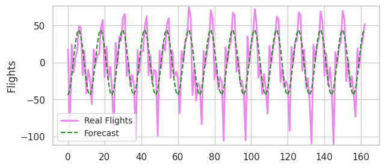

```python
# Plotting
plt.figure(figsize=(7, 3))
plt.plot(flt, color='violet', linewidth=2, label='Real Flights')
plt.plot(b_flt, color='forestgreen', linestyle='--', label='Forecast')
plt.ylim(mini_flt, maxi_flt)
plt.xlabel('')
plt.ylabel('Flights')
plt.legend(loc='lower left', fontsize=10)
plt.show()
```

*Periodogram*

The plot of the peridogram estimates the spectral density of flights across different frequencies. This helps us to know the strength of the signal at a specific frequency.

```python
train_data.index = pd.to_datetime(train_data.index)
# Calculate the periodogram
freqs_flt, spectrum_flt = periodogram(train_data['Flt'], detrend='linear')
```

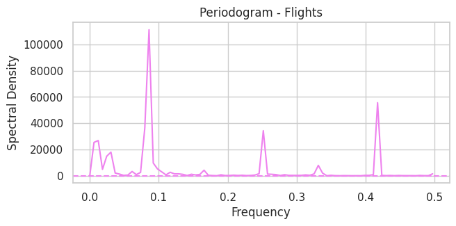

```python
# Plotting
plt.figure(figsize=(7, 3))
plt.plot(freqs_flt, spectrum_flt, color='violet')
plt.xlabel('Frequency')
plt.ylabel('Spectral Density')
plt.title('Periodogram - Flights')
plt.axhline(y=0, color='violet', linestyle='--')
plt.grid(True)
plt.show()
```

```python
# Sort the spectrum values in descending order
sorted_indices_flt = np.argsort(spectrum_flt)[::-1]  # Get sorted indices in descending order
max_indices_flt = sorted_indices_flt[:2]  # Get the indices of the top 2 maximum values

# Get the maximum spectrum values and corresponding frequencies
max_values_flt = spectrum_flt[max_indices_flt]
corresponding_freqs_flt = freqs_flt[max_indices_flt]

# Print the maximum values and corresponding frequencies
print("Maximum values of periodogram:", max_values_flt) #importancia maxima
print("Corresponding frequencies:", corresponding_freqs_flt) #en que momento se da esa impostancia maxima si hacemos 1/0.086 approx = 12

#MSE
MSE_flt_harmonic = mean_squared_error(flt,b_flt)
print("Flights MSE: ", MSE_flt_harmonic)
```

```
Maximum values of periodogram: [111179.93830243  55615.61883109]
Corresponding frequencies: [0.08588957 0.41717791]
Flights MSE:  760.0375364864291
```

In this periodogram, we can identify the dominant frequency, which is approximately at the frequency $≈ 0.08$, corresponding to a cycle of $\frac{1}{0.08} \approx 12.5$ months. This suggests that the dominant frequency of 0.0859 cycles per month might correspond to a repeating pattern approximately every year. The second maximum of the spectral density is in 0.4172 cycles per month which might correspond to a more frequent pattern, occurring approximately every 2 month.

#### Domestic and International

We followed the same process as we have done before for examining domestic and international flight data. This involved steps such as doing an harmonic regression and plotting the periodogram to identify dominant frequencies and patterns within each dataset.

```python
# Subtract trend from 'Dom_Flt' and 'Int_Flt'
dom_flt_detrended = train_data['Dom_Flt'] - dec_result_dom_flt.trend
int_flt_detrended = train_data['Int_Flt'] - dec_result_int_flt.trend

# Create time index
f = np.arange(len(dom_flt_detrended)) + 1

# Create sine and cosine components
sine = np.sin(f * 2 * np.pi / 12)
cosine = np.cos(f * 2 * np.pi / 12)

# Create the design matrix for domestic flights
X_dom = pd.DataFrame({'sine': sine, 'cosine': cosine})

# Add constant to the model for domestic flights
X_dom = sm.add_constant(X_dom)

# Resetting indices to match for domestic flights
dom_flt_detrended = dom_flt_detrended.reset_index(drop=True)

# Fit the linear regression model for domestic flights
model_dom = sm.OLS(dom_flt_detrended, X_dom)
flt_results_harmonic_dom = model_dom.fit()

# Print summary of the regression results for domestic flights
print("Domestic Flights Regression Results:")
print(flt_results_harmonic_dom.summary())

# Create the design matrix for international flights
X_int = pd.DataFrame({'sine': sine, 'cosine': cosine})

# Add constant to the model for international flights
X_int = sm.add_constant(X_int)

# Resetting indices to match for international flights and to avoid getting error
int_flt_detrended = int_flt_detrended.reset_index(drop=True)

# Fit the linear regression model for international flights
model_int = sm.OLS(int_flt_detrended, X_int)
flt_results_harmonic_int = model_int.fit()

# Print summary of the regression results for international flights
print("\nInternational Flights Regression Results:")
print(flt_results_harmonic_int.summary())
```

```
Domestic Flights Regression Results:
                            OLS Regression Results
==============================================================================
Dep. Variable:                      y   R-squared:                       0.575
Model:                            OLS   Adj. R-squared:                  0.570
Method:                 Least Squares   F-statistic:                     108.4
Date:                Thu, 22 Feb 2024   Prob (F-statistic):           1.72e-30
Time:                        11:22:13   Log-Likelihood:                -754.54
No. Observations:                 163   AIC:                             1515.
Df Residuals:                     160   BIC:                             1524.
Df Model:                           2
Covariance Type:            nonrobust
==============================================================================
                 coef    std err          t      P>|t|      [0.025      0.975]
------------------------------------------------------------------------------
const          0.1199      1.960      0.061      0.951      -3.752       3.991
sine         -19.9920      2.776     -7.201      0.000     -25.475     -14.509
cosine       -35.4262      2.767    -12.803      0.000     -40.891     -29.962
==============================================================================
Omnibus:                       10.894   Durbin-Watson:                   2.856
Prob(Omnibus):                  0.004   Jarque-Bera (JB):               11.188
Skew:                          -0.626   Prob(JB):                      0.00372
Kurtosis:                       3.286   Cond. No.                         1.42
==============================================================================

Notes:
[1] Standard Errors assume that the covariance matrix of the errors is correctly specified.

International Flights Regression Results:
                            OLS Regression Results
==============================================================================
Dep. Variable:                      y   R-squared:                       0.417
Model:                            OLS   Adj. R-squared:                  0.410
Method:                 Least Squares   F-statistic:                     57.32
Date:                Thu, 22 Feb 2024   Prob (F-statistic):           1.69e-19
Time:                        11:22:13   Log-Likelihood:                -444.03
No. Observations:                 163   AIC:                             894.1
Df Residuals:                     160   BIC:                             903.3
Df Model:                           2
Covariance Type:            nonrobust
==============================================================================
                 coef    std err          t      P>|t|      [0.025      0.975]
------------------------------------------------------------------------------
const          0.0112      0.292      0.038      0.970      -0.565       0.587
sine           0.8393      0.413      2.031      0.044       0.023       1.655
cosine        -4.3340      0.412    -10.524      0.000      -5.147      -3.521
==============================================================================
Omnibus:                      148.638   Durbin-Watson:                   2.012
Prob(Omnibus):                  0.000   Jarque-Bera (JB):               12.053
Skew:                           0.063   Prob(JB):                      0.00241
Kurtosis:                       1.674   Cond. No.                         1.42
==============================================================================

Notes:
[1] Standard Errors assume that the covariance matrix of the errors is correctly specified.
```

```python
# Retrieve the coefficients A and B from the results for domestic flights
A_dom_flt = flt_results_harmonic_dom.params['sine']
B_dom_flt = flt_results_harmonic_dom.params['cosine']

# Retrieve the coefficients A and B from the results for international flights
A_int_flt = flt_results_harmonic_int.params['sine']
B_int_flt = flt_results_harmonic_int.params['cosine']

# Calculate R for domestic flights
R_dom_flt = np.sqrt(A_dom_flt**2 + B_dom_flt**2)

# Calculate R for international flights
R_int_flt = np.sqrt(A_int_flt**2 + B_int_flt**2)

print("R value for Domestic Flights:", R_dom_flt)
print("R value for International Flights:", R_int_flt)
```

```
R value for Domestic Flights: 40.67800247385605
R value for International Flights: 4.414485913678945
```

```python
# Calculate theta for domestic flights
theta_dom_flt = np.arctan2(B_dom_flt, A_dom_flt)
print("Theta value for Domestic Flights:", theta_dom_flt)

# Calculate theta for international flights
theta_int_flt = np.arctan2(B_int_flt, A_int_flt)
print("Theta value for International Flights:", theta_int_flt)
```

```
Theta value for Domestic Flights: -2.0845734366794355
Theta value for International Flights: -1.379514123941018
```

```python
# Assuming flt_results_harmonic_dom and flt_results_harmonic_int are the fitted OLS models for domestic and international flights respectively
dom_flt_fitted_values = flt_results_harmonic_dom.fittedvalues
int_flt_fitted_values = flt_results_harmonic_int.fittedvalues

# Calculate the maximum and minimum for setting plot limits for domestic flights
max_dom_flt = float(np.max(dom_flt_detrended))
max_dom_flt_fitted = float(np.max(dom_flt_fitted_values))
maxi_dom_flt = max(max_dom_flt, max_dom_flt_fitted) + 1

min_dom_flt = float(np.min(dom_flt_detrended))
min_dom_flt_fitted = float(np.min(dom_flt_fitted_values))
mini_dom_flt = min(min_dom_flt, min_dom_flt_fitted) - 1

# Calculate the maximum and minimum for setting plot limits for international flights
max_int_flt = float(np.max(int_flt_detrended))
max_int_flt_fitted = float(np.max(int_flt_fitted_values))
maxi_int_flt = max(max_int_flt, max_int_flt_fitted) + 1

min_int_flt = float(np.min(int_flt_detrended))
min_int_flt_fitted = float(np.min(int_flt_fitted_values))
mini_int_flt = min(min_int_flt, min_int_flt_fitted) - 1

# Creating time series for the fitted values for domestic and international flights
dom_flt_fitted_series = pd.Series(dom_flt_fitted_values, index=dom_flt_detrended.index)
int_flt_fitted_series = pd.Series(int_flt_fitted_values, index=int_flt_detrended.index)
```

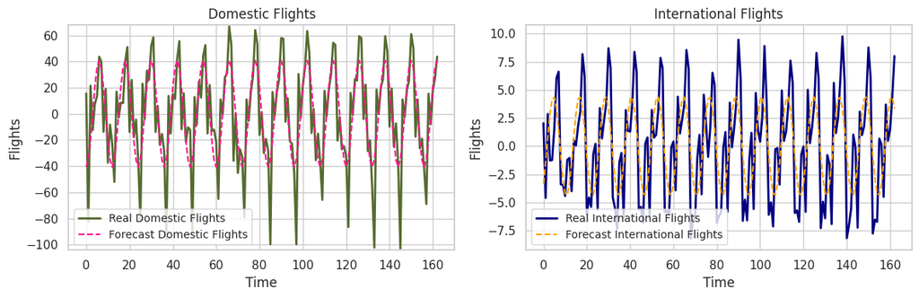

```python
# Create subplots
fig, (ax1, ax2) = plt.subplots(1, 2, figsize=(12, 4))

# Plotting for domestic flights
ax1.plot(dom_flt_detrended.index, dom_flt_detrended, color='darkolivegreen', linewidth=2, label='Real Domestic Flights')
ax1.plot(dom_flt_fitted_series.index, dom_flt_fitted_series, color='deeppink', linestyle='--', label='Forecast Domestic Flights')
ax1.set_ylim(mini_dom_flt, maxi_dom_flt)
ax1.set_xlabel('Time')
ax1.set_ylabel('Flights')
ax1.legend(loc='lower left', fontsize=10)
ax1.set_title('Domestic Flights')

# Plotting for international flights
ax2.plot(int_flt_detrended.index, int_flt_detrended, color='navy', linewidth=2, label='Real International Flights')
ax2.plot(int_flt_fitted_series.index, int_flt_fitted_series, color='orange', linestyle='--', label='Forecast International Flights')
ax2.set_ylim(mini_int_flt, maxi_int_flt)
ax2.set_xlabel('Time')
ax2.set_ylabel('Flights')
ax2.legend(loc='lower left', fontsize=10)
ax2.set_title('International Flights')

plt.tight_layout()
plt.show()
```

```python
# Calculate the periodogram for domestic flights
freqs_dom_flt, spectrum_dom_flt = periodogram(train_data['Dom_Flt'], detrend='linear')
# Calculate the periodogram for international flights
freqs_int_flt, spectrum_int_flt = periodogram(train_data['Int_Flt'], detrend='linear')
```

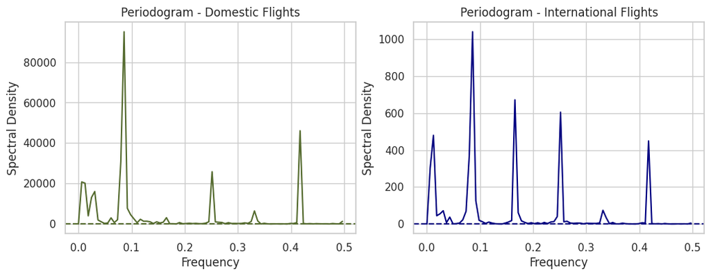

```python
# Create subplots
fig, (ax1, ax2) = plt.subplots(1, 2, figsize=(12, 4))

# Plotting for domestic flights
ax1.plot(freqs_dom_flt, spectrum_dom_flt, color='darkolivegreen')
ax1.set_xlabel('Frequency')
ax1.set_ylabel('Spectral Density')
ax1.set_title('Periodogram - Domestic Flights')
ax1.axhline(y=0, color='darkolivegreen', linestyle='--')
ax1.grid(True)

# Plotting for international flights
ax2.plot(freqs_int_flt, spectrum_int_flt, color='navy')
ax2.set_xlabel('Frequency')
ax2.set_ylabel('Spectral Density')
ax2.set_title('Periodogram - International Flights')
ax2.axhline(y=0, color='navy', linestyle='--')
ax2.grid(True)

plt.show()
```

```python
# Sort the spectrum values in descending order for domestic flights
sorted_indices_dom_flt = np.argsort(spectrum_dom_flt)[::-1]  # Get sorted indices in descending order
max_indices_dom_flt = sorted_indices_dom_flt[:2]  # Get the indices of the top 2 maximum values

# Get the maximum spectrum values and corresponding frequencies for domestic flights
max_values_dom_flt = spectrum_dom_flt[max_indices_dom_flt]
corresponding_freqs_dom_flt = freqs_dom_flt[max_indices_dom_flt]

# Print the maximum values and corresponding frequencies for domestic flights
print("Maximum values of periodogram for Domestic Flights:", max_values_dom_flt)
print("Corresponding frequencies for Domestic Flights:", corresponding_freqs_dom_flt)

# Calculate Mean Squared Error (MSE) for harmonic model for domestic flights
MSE_dom_flt_harmonic = mean_squared_error(dom_flt_detrended, dom_flt_fitted_series)
print("Mean Squared Error (MSE) for Domestic Flights (Harmonic Model):", MSE_dom_flt_harmonic)

# Sort the spectrum values in descending order for international flights
sorted_indices_int_flt = np.argsort(spectrum_int_flt)[::-1]  # Get sorted indices in descending order
max_indices_int_flt = sorted_indices_int_flt[:2]  # Get the indices of the top 2 maximum values

# Get the maximum spectrum values and corresponding frequencies for international flights
max_values_int_flt = spectrum_int_flt[max_indices_int_flt]
corresponding_freqs_int_flt = freqs_int_flt[max_indices_int_flt]

# Print the maximum values and corresponding frequencies for international flights
print("\nMaximum values of periodogram for International Flights:", max_values_int_flt)
print("Corresponding frequencies for International Flights:", corresponding_freqs_int_flt)

# Calculate Mean Squared Error (MSE) for harmonic model for international flights
MSE_int_flt_harmonic = mean_squared_error(int_flt_detrended, int_flt_fitted_series)
print("Mean Squared Error (MSE) for International Flights (Harmonic Model):", MSE_int_flt_harmonic)
```

```
Maximum values of periodogram for Domestic Flights: [95034.39083231 46093.9182659 ]
Corresponding frequencies for Domestic Flights: [0.08588957 0.41717791]
Mean Squared Error (MSE) for Domestic Flights (Harmonic Model): 614.2036767330362

Maximum values of periodogram for International Flights: [1039.90839831  671.64279491]
Corresponding frequencies for International Flights: [0.08588957 0.16564417]
Mean Squared Error (MSE) for International Flights (Harmonic Model): 13.603974563877522
```

Not only for the domestic flight but also for the international flights, the dominant frequency appears in approximately 0.086 cycles per month. We can conclude that both series have repeating pattern approximately every year, so both time series has a strong seasonal that repeat aprroximatly every year. Finally, we have the secondary peak that means a more frequent pattern, occurring approximately every 2 month for domestic flights and every 6 month for international flights.

## Best model in terms of predictions and MSE

**Mean Squeared Error**

To evaluate the fitted models, we will use the Mean Squeared Error (MSE) as our metric for compare them.

- Total of Flights

```python
MSE_Flights = {
    'Model': ['Holt-Winters', 'Neural Network', 'Harmonic Regression'],
    'MSE': [MSE_flt_HW, MSE_flt_NN, MSE_flt_harmonic]
}
MSE_Flights = pd.DataFrame(MSE_Flights)
MSE_Flights['MSE'] = MSE_Flights['MSE'].round(2)
MSE_Flights['MSE'] = MSE_Flights['MSE'].astype(str)
print(MSE_Flights)
```

```
                 Model      MSE
0         Holt-Winters  1726.65
1       Neural Network   900.48
2  Harmonic Regression   760.04
```

- Total of Domestic Flights

```python
MSE_Domestic_Flights = {
    'Model': ['Holt-Winters', 'Neural Network', 'Harmonic Regression'],
    'MSE': [MSE_dom_flt_HW, MSE_dom_flt_NN, MSE_dom_flt_harmonic]
}
MSE_Domestic_Flights = pd.DataFrame(MSE_Domestic_Flights)
MSE_Domestic_Flights['MSE'] = MSE_Domestic_Flights['MSE'].round(2)
MSE_Domestic_Flights['MSE'] = MSE_Domestic_Flights['MSE'].astype(str)
print(MSE_Domestic_Flights)
```

```
                 Model      MSE
0         Holt-Winters  1803.59
1       Neural Network  1420.93
2  Harmonic Regression    614.2
```

For domestic flights the situation is similar to the total of flights, the Harmonic Regression present the smallest MSE.

- Total of International Flights

```python
MSE_International_Flights = {
    'Model': ['Holt-Winters', 'Neural Network', 'Harmonic Regression'],
    'MSE': [MSE_int_flt_HW, MSE_int_flt_NN, MSE_int_flt_harmonic]
}
MSE_International_Flights = pd.DataFrame(MSE_International_Flights)
MSE_International_Flights['MSE'] = MSE_International_Flights['MSE'].round(2)
MSE_International_Flights['MSE'] = MSE_International_Flights['MSE'].astype(str)
print(MSE_International_Flights)
```

```
                 Model    MSE
0         Holt-Winters   4.78
1       Neural Network  14.29
2  Harmonic Regression   13.6
```

For international flights the situation is quite different, the Holt-Winters model is the one with the smallest MSE. This could be attributed to the disproportion between the volume of domestic flights compared to international ones.